# Peer-graded Assignment: Course Project 1

# Reproducible Research

In this report the process and results are shown of the analysis of activity monitor data. The data is collected in October and November 2012 of a single subject. Every 5 minute interval the number of steps taken in that interval are collected. In the following steps the data is loaded, processed and analysed.

## Loading and preprocessing the data

1. Load the data (i.e. read.csv())
2. Process/transform the data (if necessary) into a format suitable for your analysis

```r
activity <- read.csv2("Activity.csv", header=TRUE, sep= ",", fill = TRUE)
activity$date <- as.Date(as.character(activity$date, format = "%m/%d/%Y"))
```

## Analyzing and reporting the data

### What is mean total number of steps taken per day?

1. Calculate the total number of steps taken per day

```r
stepsDate <- aggregate(steps ~ date, activity, sum)
```

2. Make a histogram of the total number of steps taken each day

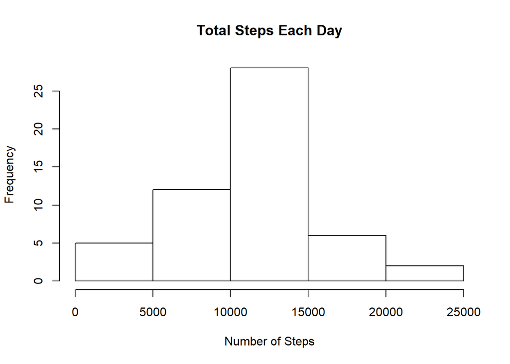

```r
hist(stepsDate$steps, main ="Total Steps Each Day", xlab="Number of Steps")
```

```r
stepsDatemean <- mean(stepsDate$steps)
stepsDatemedian <- median(stepsDate$steps)
```

### What is the average daily activity pattern?

1. Make a time series plot (i.e. type = “l”) of the 5-minute interval (x-axis) and the average number of steps taken, averaged across all days (y-axis)

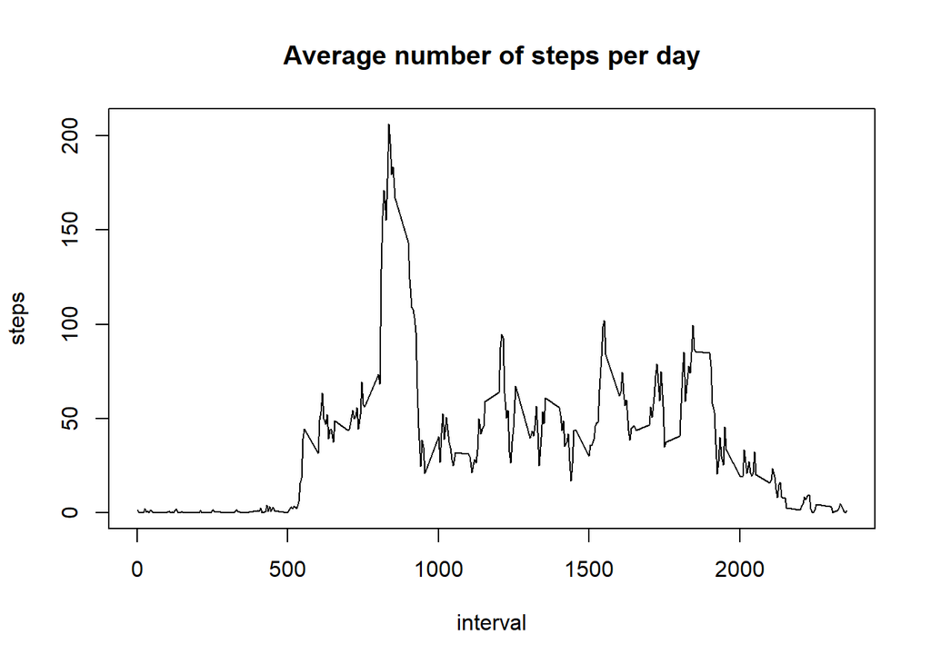

```r
#first calculate average number of steps taken each day
stepsMean <- aggregate(steps ~ interval, activity, mean)
plot(stepsMean, type= "l", main='Average number of steps per day')
```

2. Which 5-minute interval, on average across all the days in the dataset, contains the maximum number of steps?

```r
stepsMax <- stepsMean[which.max(stepsMean$steps),1]
```

The interval with on average the maximum number of steps is 835.

### Imputing missing values

1. Calculate and report the total number of missing values in the dataset (i.e. the total number of rows with NAs)

```r
SumNAs <- sum(is.na(activity))
```

The total number of missing values is: 2304.

2. Devise a strategy for filling in all of the missing values in the dataset. The strategy does not need to be sophisticated. For example, you could use the mean/median for that day, or the mean for that 5-minute interval, etc.
3. Create a new dataset that is equal to the original dataset but with the missing data filled in. Both steps are performed in one go.

```r
library(Hmisc)
# creating new data set
activityImputed <- activity
# imputing NA's with median value for that day, i.e. default.
activityImputed$steps <- impute(activity$steps)
```

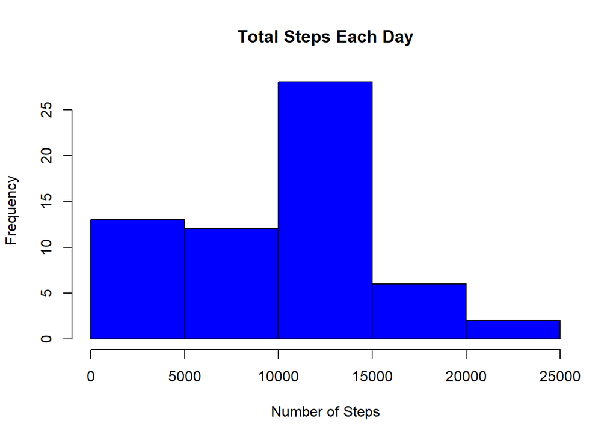

```r
# configure to show numbers not scientific and with only 2 digits after the .
options(scipen = 999, digits = "2")
stepsDateImputed <- aggregate(steps ~ date, activityImputed, sum)
stepsDateImputedmean <- mean(stepsDateImputed$steps)
stepsDateImputedmedian <- median(stepsDateImputed$steps)
hist(stepsDateImputed$steps, main ="Total Steps Each Day", col="blue", xlab="Number of Steps")
```

### Are there differences in activity patterns between weekdays and weekends?

1. Create a new factor variable in the dataset with two levels - “weekday” and “weekend” indicating whether a given date is a weekday or weekend day.

```r
activityImputed$dateType <- ifelse(as.POSIXlt(activityImputed$date)$wday %in% c(0,6), 'weekend', 'weekday')
```

2. Make a panel plot containing a time series plot (i.e. type = “l”) of the 5-minute interval (x-axis) and the average number of steps taken, averaged across all weekday days or weekend days (y-axis).

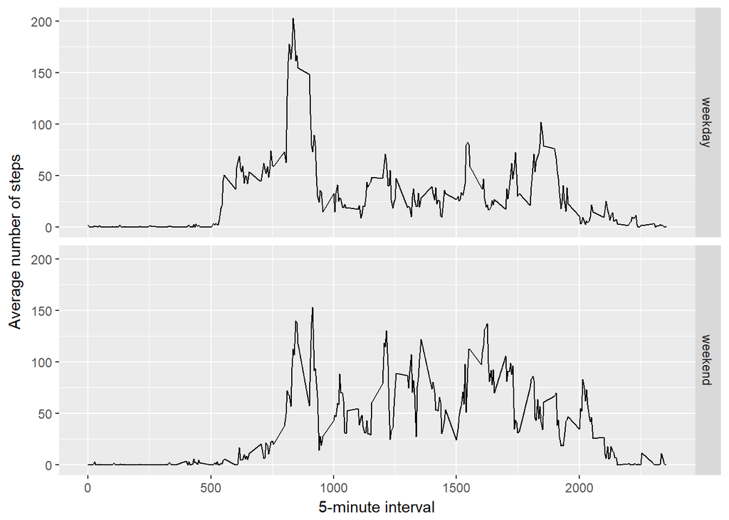

```r
# create average per date type
activityImputedMean <- aggregate(steps~interval+ dateType, data=activityImputed, mean)
par(mfrow=c(1,2))
ggplot(activityImputedMean, aes(interval, steps)) +  geom_line() + facet_grid(dateType ~ .) +xlab("5-minute interval") +  ylab("Average number of steps")
```